# CSE3020 Lab6

Faraz Suhail

11/03/2022

## Name: “Faraz Suhail”

## Reg. No.: “19BCE1525”

```r
library(igraph)
```

1. Read the given adjacency matrix into R (Adjacency.csv)
2. Read the given edge matrix into R(Edges.csv)

```r
matrix = read.csv("Lab6-DataSet_Adjacency.csv")
edge = read.csv("Lab6-DataSet_Edges.csv")
head(matrix)
```

```
##      X X2000 X2001 X2002 X2003 X2004 X2005 X2006 X2007 X2008 X2009 X2010
## 1 2000     0     1     0     1     0     1     0     1     0     0     0
## 2 2001     1     1     1     0     1     0     1     1     0     1     1
## 3 2002     1     1     0     0     1     0     0     0     0     0     0
## 4 2003     1     1     1     0     0     1     0     1     0     1     0
## 5 2004     1     0     1     0     0     1     0     1     0     1     1
## 6 2005     0     0     1     1     1     0     1     0     0     0     1
```

```r
head(edge)
```

```
##     V1   V2
## 1 2000 2001
## 2 2001 2002
## 3 2002 2004
## 4 2003 2004
## 5 2004 2003
## 6 2004 2002
```

```r
rownames(matrix) = seq(2000, 2010, length.output = 11)
```

3. Create and plot the graph from the adjacency matrix and edge matrix (customize the vertex color edge size, vertex frame and label)

```r
matrix1 = matrix[2:12]
colnames(matrix1) = seq(2000, 2010, length.output = 11)
head(matrix1)
```

```
##      2000 2001 2002 2003 2004 2005 2006 2007 2008 2009 2010
## 2000    0    1    0    1    0    1    0    1    0    0    0
## 2001    1    1    1    0    1    0    1    1    0    1    1
## 2002    1    1    0    0    1    0    0    0    0    0    0
## 2003    1    1    1    0    0    1    0    1    0    1    0
## 2004    1    0    1    0    0    1    0    1    0    1    1
## 2005    0    0    1    1    1    0    1    0    0    0    1
```

```r
matrix1 = data.matrix(matrix1)
head(matrix1)
```

```
##      2000 2001 2002 2003 2004 2005 2006 2007 2008 2009 2010
## 2000    0    1    0    1    0    1    0    1    0    0    0
## 2001    1    1    1    0    1    0    1    1    0    1    1
## 2002    1    1    0    0    1    0    0    0    0    0    0
## 2003    1    1    1    0    0    1    0    1    0    1    0
## 2004    1    0    1    0    0    1    0    1    0    1    1
## 2005    0    0    1    1    1    0    1    0    0    0    1
```

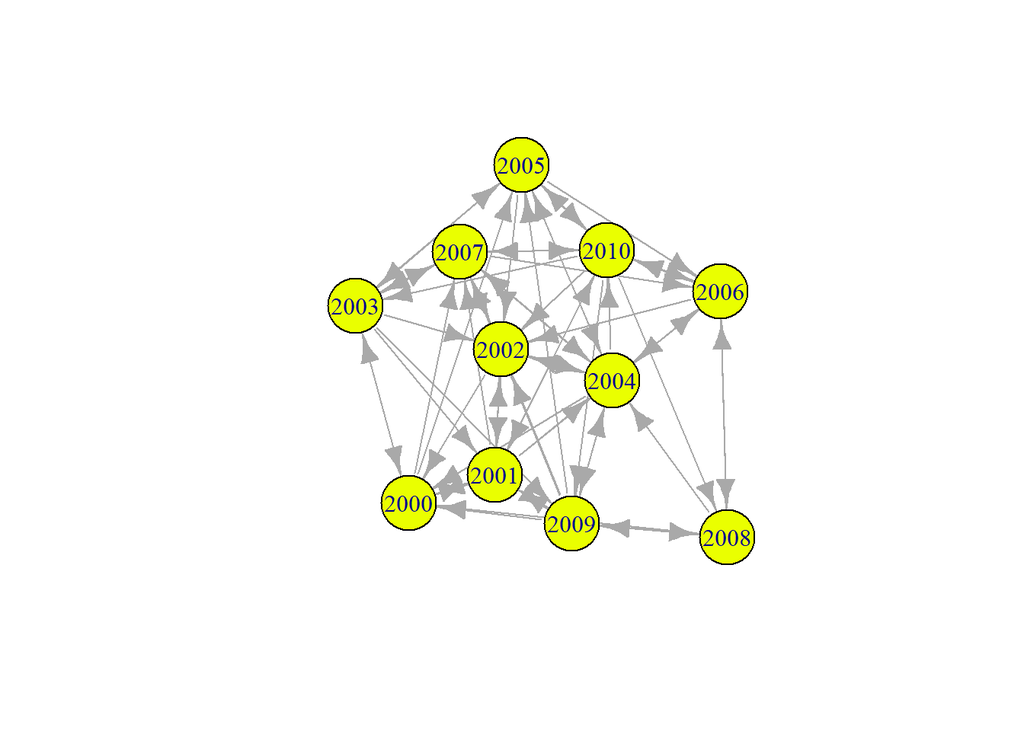

```r
g = graph_from_adjacency_matrix(matrix1,diag = FALSE)
plot(g,vertex.color = "#eaff00",vertex.size=30)
```

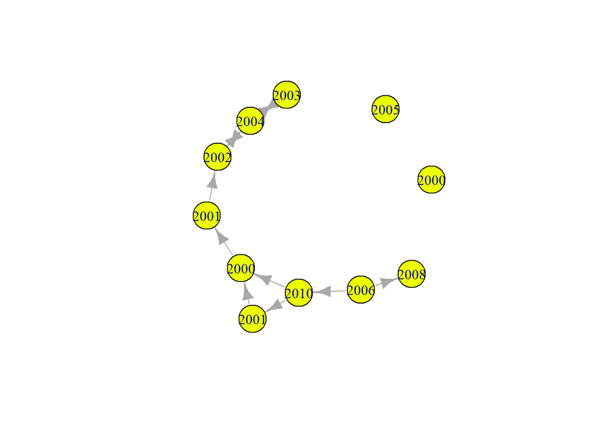

```r
g2 = graph.empty(n=11)
g2 = add.edges(g2,c(1,2, 2,3, 3,5, 4,5, 5,4, 5,3, 7,9, 7,8, 9,11, 9,1, 11,1))
plot(g2,vertex.label=c(2000,2001,2002,2003,2004,2005,2006, 2008,2010),vertex.color = "#eaff00",vertex.size=25)
```

4. Display the edges & vertices, the network as matrix and the names of vertices

```r
print(E(g))
```

```
## + 59/59 edges from 4c3ee28 (vertex names):
##  [1] 2000->2001 2000->2003 2000->2005 2000->2007 2001->2000 2001->2002
##  [7] 2001->2004 2001->2006 2001->2007 2001->2009 2001->2010 2002->2000
## [13] 2002->2001 2002->2004 2003->2000 2003->2001 2003->2002 2003->2005
## [19] 2003->2007 2003->2009 2004->2000 2004->2002 2004->2005 2004->2007
## [25] 2004->2009 2004->2010 2005->2002 2005->2003 2005->2004 2005->2006
## [31] 2005->2010 2006->2002 2006->2004 2006->2008 2006->2010 2007->2002
## [37] 2007->2003 2007->2004 2007->2006 2007->2010 2008->2000 2008->2004
## [43] 2008->2006 2008->2009 2009->2000 2009->2001 2009->2002 2009->2004
## [49] 2009->2005 2009->2007 2009->2008 2010->2001 2010->2002 2010->2003
## [55] 2010->2005 2010->2006 2010->2007 2010->2008 2010->2009
```

```r
print(V(g))
```

```
## + 11/11 vertices, named, from 4c3ee28:
##  [1] 2000 2001 2002 2003 2004 2005 2006 2007 2008 2009 2010
```

5. Find the count of vertices and edges of the created graph

```r
print(E(g2))
```

```
## + 11/11 edges from 4c9c750:
##  [1]  1-> 2  2-> 3  3-> 5  4-> 5  5-> 4  5-> 3  7-> 9  7-> 8  9->11  9-> 1
## [11] 11-> 1
```

```r
print(V(g2))
```

```
## + 11/11 vertices, from 4c9c750:
##  [1]  1  2  3  4  5  6  7  8  9 10 11
```

6. Display the adjacency vertices of each vertex(individual) in the created graph
7. Find the min and max degree of the created graph

```r
print(get.adjacency(g))
```

```
## 11 x 11 sparse Matrix of class "dgCMatrix"
```

```
##    [[ suppressing 11 column names '2000', '2001', '2002' ... ]]
```

```
##
## 2000 . 1 . 1 . 1 . 1 . . .
## 2001 1 . 1 . 1 . 1 1 . 1 1
## 2002 1 1 . . 1 . . . . . .
## 2003 1 1 1 . . 1 . 1 . 1 .
## 2004 1 . 1 . . 1 . 1 . 1 1
## 2005 . . 1 1 1 . 1 . . . 1
## 2006 . . 1 . 1 . . . 1 . 1
## 2007 . . 1 1 1 . 1 . . . 1
## 2008 1 . . . 1 . 1 . . 1 .
## 2009 1 1 1 . 1 1 . 1 1 . .
## 2010 . 1 1 1 . 1 1 1 1 1 .
```

```r
print(get.adjacency(g2))
```

```
## 11 x 11 sparse Matrix of class "dgCMatrix"
##
##  [1,] . 1 . . . . . . . . .
##  [2,] . . 1 . . . . . . . .
##  [3,] . . . . 1 . . . . . .
##  [4,] . . . . 1 . . . . . .
##  [5,] . . 1 1 . . . . . . .
##  [6,] . . . . . . . . . . .
##  [7,] . . . . . . . 1 1 . .
##  [8,] . . . . . . . . . . .
##  [9,] 1 . . . . . . . . . 1
## [10,] . . . . . . . . . . .
## [11,] 1 . . . . . . . . . .
```

```r
V(g)$names = seq(2000,2010)
V(g2)$names = c(2000,2001,2002,2003,2004,2005,2006,2008,2010)
print(V(g)$names)
```

```
##  [1] 2000 2001 2002 2003 2004 2005 2006 2007 2008 2009 2010
```

```r
print(V(g2)$names)
```

```
##  [1] 2000 2001 2002 2003 2004 2005 2006 2008 2010 2000 2001
```

```r
print(vcount(g))
```

```
## [1] 11
```

```r
print(ecount(g))
```

```
## [1] 59
```

```r
print(vcount(g2))
```

```
## [1] 11
```

```r
print(ecount(g2))
```

```
## [1] 11
```

```r
print(get.adjedgelist(g))
```

```
## $`2000`
## + 10/59 edges from 4c3ee28 (vertex names):
##  [1] 2000->2001 2000->2003 2000->2005 2000->2007 2001->2000 2002->2000
##  [7] 2003->2000 2004->2000 2008->2000 2009->2000
##
## $`2001`
## + 12/59 edges from 4c3ee28 (vertex names):
##  [1] 2001->2000 2001->2002 2001->2004 2001->2006 2001->2007 2001->2009
##  [7] 2001->2010 2000->2001 2002->2001 2003->2001 2009->2001 2010->2001
##
## $`2002`
## + 11/59 edges from 4c3ee28 (vertex names):
##  [1] 2002->2000 2002->2001 2002->2004 2001->2002 2003->2002 2004->2002
##  [7] 2005->2002 2006->2002 2007->2002 2009->2002 2010->2002
##
## $`2003`
## + 10/59 edges from 4c3ee28 (vertex names):
##  [1] 2003->2000 2003->2001 2003->2002 2003->2005 2003->2007 2003->2009
##  [7] 2000->2003 2005->2003 2007->2003 2010->2003
##
## $`2004`
## + 13/59 edges from 4c3ee28 (vertex names):
##  [1] 2004->2000 2004->2002 2004->2005 2004->2007 2004->2009 2004->2010
##  [7] 2001->2004 2002->2004 2005->2004 2006->2004 2007->2004 2008->2004
## [13] 2009->2004
##
## $`2005`
## + 10/59 edges from 4c3ee28 (vertex names):
##  [1] 2005->2002 2005->2003 2005->2004 2005->2006 2005->2010 2000->2005
##  [7] 2003->2005 2004->2005 2009->2005 2010->2005
##
## $`2006`
## + 9/59 edges from 4c3ee28 (vertex names):
## [1] 2006->2002 2006->2004 2006->2008 2006->2010 2001->2006 2005->2006 2007->2006
## [8] 2008->2006 2010->2006
##
## $`2007`
## + 11/59 edges from 4c3ee28 (vertex names):
##  [1] 2007->2002 2007->2003 2007->2004 2007->2006 2007->2010 2000->2007
##  [7] 2001->2007 2003->2007 2004->2007 2009->2007 2010->2007
##
## $`2008`
## + 7/59 edges from 4c3ee28 (vertex names):
## [1] 2008->2000 2008->2004 2008->2006 2008->2009 2006->2008 2009->2008 2010->2008
##
## $`2009`
## + 12/59 edges from 4c3ee28 (vertex names):
##  [1] 2009->2000 2009->2001 2009->2002 2009->2004 2009->2005 2009->2007
##  [7] 2009->2008 2001->2009 2003->2009 2004->2009 2008->2009 2010->2009
##
## $`2010`
## + 13/59 edges from 4c3ee28 (vertex names):
##  [1] 2010->2001 2010->2002 2010->2003 2010->2005 2010->2006 2010->2007
##  [7] 2010->2008 2010->2009 2001->2010 2004->2010 2005->2010 2006->2010
## [13] 2007->2010
```

```r
print(get.adjedgelist(g2))
```

```
## [[1]]
## + 3/11 edges from 4c9c750:
## [1]  1->2  9->1 11->1
##
## [[2]]
## + 2/11 edges from 4c9c750:
## [1] 2->3 1->2
##
## [[3]]
## + 3/11 edges from 4c9c750:
## [1] 3->5 2->3 5->3
##
## [[4]]
## + 2/11 edges from 4c9c750:
## [1] 4->5 5->4
##
## [[5]]
## + 4/11 edges from 4c9c750:
## [1] 5->3 5->4 3->5 4->5
##
## [[6]]
## + 0/11 edges from 4c9c750:
##
## [[7]]
## + 2/11 edges from 4c9c750:
## [1] 7->8 7->9
##
## [[8]]
## + 1/11 edge from 4c9c750:
## [1] 7->8
##
## [[9]]
## + 3/11 edges from 4c9c750:
## [1] 9-> 1 9->11 7-> 9
##
## [[10]]
## + 0/11 edges from 4c9c750:
##
## [[11]]
## + 2/11 edges from 4c9c750:
## [1] 11-> 1  9->11
```

8. Create & set vertex attribute property named profit and values(“+”, “-”, “+”, “-”, “+”, “-”,“+”, “-”, “+”)

```r
V(g)$profit =c("+", "-", "+", "-", "+", "-","+","-","+")
print(V(g)$profit)
```

```
##  [1] "+" "-" "+" "-" "+" "-" "+" "-" "+" "+" "-"
```

```r
V(g2)$profit =c("+", "-", "+", "-", "+", "-","+","-","+")
print(V(g2)$profit)
```

```
##  [1] "+" "-" "+" "-" "+" "-" "+" "-" "+" "+" "-"
```

9. Create & set vertex attribute property named type and values(either leap or non-leap year)

```r
V(g)[(names %% 4)==0]$type = "leap"
V(g)[(names %% 4)!=0]$type = "non-leap"
V(g2)[(names %% 4)==0]$type = "leap"
V(g2)[(names %% 4)!=0]$type = "non-leap"
print(V(g)$type)
```

```
##  [1] "leap"     "non-leap" "non-leap" "non-leap" "leap"     "non-leap"
##  [7] "non-leap" "non-leap" "leap"     "non-leap" "non-leap"
```

```r
print(V(g2)$type)
```

```
##  [1] "leap"     "non-leap" "non-leap" "non-leap" "leap"     "non-leap"
##  [7] "non-leap" "leap"     "non-leap" "leap"     "non-leap"
```

10. Create & set edge attribute named weight and values (if edge exits in between leap year vertices then 5 else 1 )

```r
g = delete_vertex_attr(g,"names")
E(g)$weight = 1
E(g2)$weight= 1
E(g)[21]$weight=5
E(g)[41]$weight=5
E(g)[42]$weight=5
E(g2)[9]$weight = 5
```

11. Convert the created un-directed graph into directed graph based on the following rule:
1. edge directed towards high value vertex
2. if any one of the vertex is leap year then put the reverse edge with same weight
12. Display the adjacency matrix of the resultant directed graph.

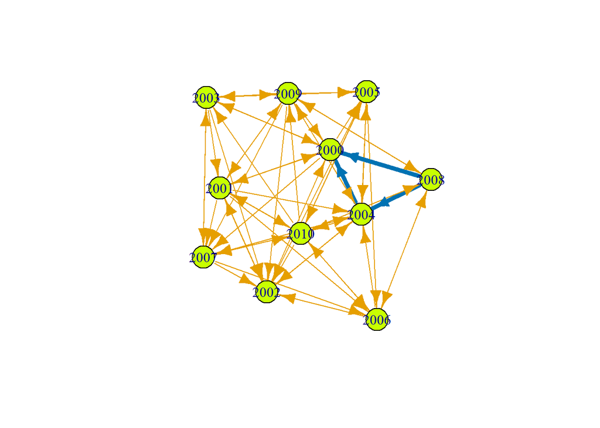

```r
plot(g,edge.color = E(g)$weight,vertex.size=20,edge.width=E(g)$weight,vertex.color="#c8ff00")
```

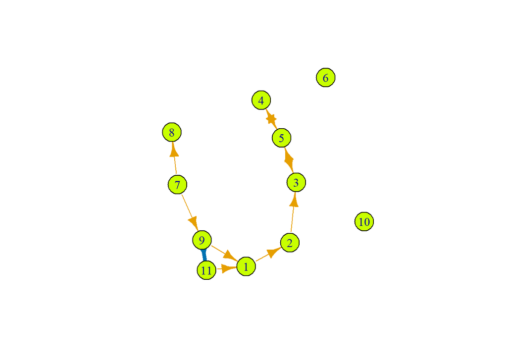

```r
plot(g2,edge.color = E(g2)$weight,vertex.size=20,edge.width=E(g2)$weight,vertex.color="#c8ff00")
```

13. Display the in-degree and out-degree of each vertex of resultant directed graph

```r
print(get.adjacency(g))
```

```
## 11 x 11 sparse Matrix of class "dgCMatrix"
```

```
##    [[ suppressing 11 column names '2000', '2001', '2002' ... ]]
```

```
##
## 2000 . 1 . 1 . 1 . 1 . . .
## 2001 1 . 1 . 1 . 1 1 . 1 1
## 2002 1 1 . . 1 . . . . . .
## 2003 1 1 1 . . 1 . 1 . 1 .
## 2004 1 . 1 . . 1 . 1 . 1 1
## 2005 . . 1 1 1 . 1 . . . 1
## 2006 . . 1 . 1 . . . 1 . 1
## 2007 . . 1 1 1 . 1 . . . 1
## 2008 1 . . . 1 . 1 . . 1 .
## 2009 1 1 1 . 1 1 . 1 1 . .
## 2010 . 1 1 1 . 1 1 1 1 1 .
```

```r
print(get.adjacency(g2))
```

```
## 11 x 11 sparse Matrix of class "dgCMatrix"
##
##  [1,] . 1 . . . . . . . . .
##  [2,] . . 1 . . . . . . . .
##  [3,] . . . . 1 . . . . . .
##  [4,] . . . . 1 . . . . . .
##  [5,] . . 1 1 . . . . . . .
##  [6,] . . . . . . . . . . .
##  [7,] . . . . . . . 1 1 . .
##  [8,] . . . . . . . . . . .
##  [9,] 1 . . . . . . . . . 1
## [10,] . . . . . . . . . . .
## [11,] 1 . . . . . . . . . .
```

```r
print(degree(g,mode="in"))
```

```
## 2000 2001 2002 2003 2004 2005 2006 2007 2008 2009 2010
##    6    5    8    4    7    5    5    6    3    5    5
```

```r
print(degree(g,mode="out"))
```

```
## 2000 2001 2002 2003 2004 2005 2006 2007 2008 2009 2010
##    4    7    3    6    6    5    4    5    4    7    8
```

```r
print(degree(g2,mode="in"))
```

```
##  [1] 2 1 2 1 2 0 0 1 1 0 1
```

```r
print(degree(g2,mode="out"))
```

```
##  [1] 1 1 1 1 2 0 2 0 2 0 1
```